# SentimentAnalysis

```python
import pandas as pd
import matplotlib.pyplot as plt
import seaborn as sns
sns.set(style="dark")
from sklearn.metrics import confusion_matrix, ConfusionMatrixDisplay, classification_report, roc_curve, auc
from sklearn.linear_model import LogisticRegression
from sklearn.naive_bayes import MultinomialNB, ComplementNB, BernoulliNB
from sklearn.feature_extraction.text import TfidfVectorizer, CountVectorizer
from sklearn.linear_model import SGDClassifier
from sklearn.model_selection import train_test_split
import joblib
import warnings
from wordcloud import WordCloud

warnings.filterwarnings(action='ignore', category=Warning)
```

```python
df = pd.read_csv('./data/sentimentTwitter.csv', encoding='ISO-8859-1')
df.head()
```

|  | 0 | 1467810369 | Mon Apr 06 22:19:45 PDT 2009 | NO_QUERY | _TheSpecialOne_ | @switchfoot http://twitpic.com/2y1zl - Awww, that's a bummer. You shoulda got David Carr of Third Day to do it. ;D |
| --- | --- | --- | --- | --- | --- | --- |
| 0 | 0 | 1467810672 | Mon Apr 06 22:19:49 PDT 2009 | NO_QUERY | scotthamilton | is upset that he can't update his Facebook by ... |
| 1 | 0 | 1467810917 | Mon Apr 06 22:19:53 PDT 2009 | NO_QUERY | mattycus | @Kenichan I dived many times for the ball. Man... |
| 2 | 0 | 1467811184 | Mon Apr 06 22:19:57 PDT 2009 | NO_QUERY | ElleCTF | my whole body feels itchy and like its on fire |
| 3 | 0 | 1467811193 | Mon Apr 06 22:19:57 PDT 2009 | NO_QUERY | Karoli | @nationwideclass no, it's not behaving at all.... |
| 4 | 0 | 1467811372 | Mon Apr 06 22:20:00 PDT 2009 | NO_QUERY | joy_wolf | @Kwesidei not the whole crew |

```python
df.columns = ['Target', 'ID', 'Date', 'Flag', 'User', 'Text']
```

```python
df.head()
```

|  | Target | ID | Date | Flag | User | Text |
| --- | --- | --- | --- | --- | --- | --- |
| 0 | 0 | 1467810672 | Mon Apr 06 22:19:49 PDT 2009 | NO_QUERY | scotthamilton | is upset that he can't update his Facebook by ... |
| 1 | 0 | 1467810917 | Mon Apr 06 22:19:53 PDT 2009 | NO_QUERY | mattycus | @Kenichan I dived many times for the ball. Man... |
| 2 | 0 | 1467811184 | Mon Apr 06 22:19:57 PDT 2009 | NO_QUERY | ElleCTF | my whole body feels itchy and like its on fire |
| 3 | 0 | 1467811193 | Mon Apr 06 22:19:57 PDT 2009 | NO_QUERY | Karoli | @nationwideclass no, it's not behaving at all.... |
| 4 | 0 | 1467811372 | Mon Apr 06 22:20:00 PDT 2009 | NO_QUERY | joy_wolf | @Kwesidei not the whole crew |

```python
df.drop(['ID', 'Flag', 'User'],axis=1, inplace=True)
```

```python
df['Target'].unique()
```

```
array([0, 4], dtype=int64)
```

```python
df['Target'].replace({0:'Negative', 4: 'Positive'}, inplace=True)
```

```python
df['WeekDay'] = df['Date'].apply(lambda x: x[:3])
```

## EDA

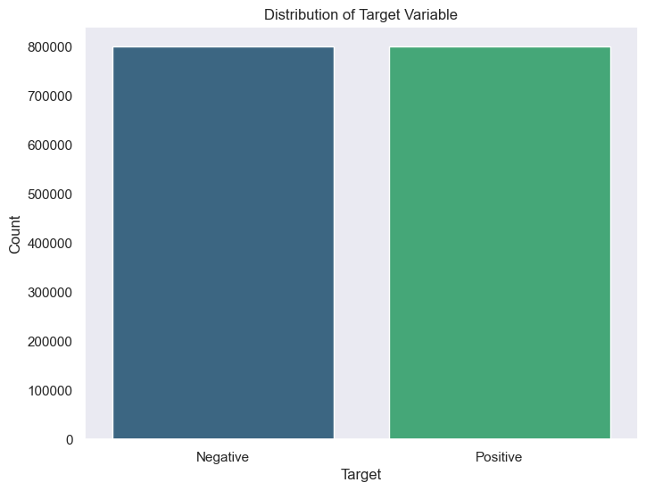

```python
plt.figure(figsize=(8, 6))
sns.countplot(x='Target', data=df, hue='Target', palette='viridis', dodge=False)
plt.title('Distribution of Target Variable')
plt.xlabel('Target')
plt.ylabel('Count')
plt.show();
```

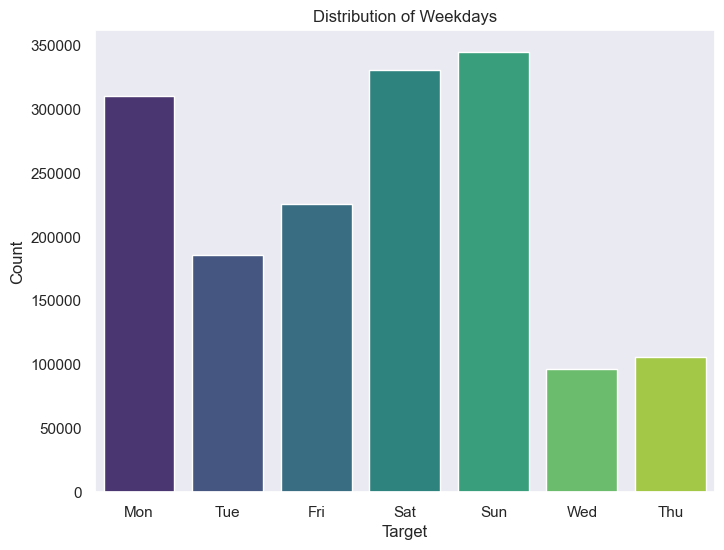

```python
plt.figure(figsize=(8, 6))
sns.countplot(x='WeekDay', data=df, hue='WeekDay', palette='viridis', dodge=False)
plt.title('Distribution of Weekdays')
plt.xlabel('Target')
plt.ylabel('Count')
plt.show();
```

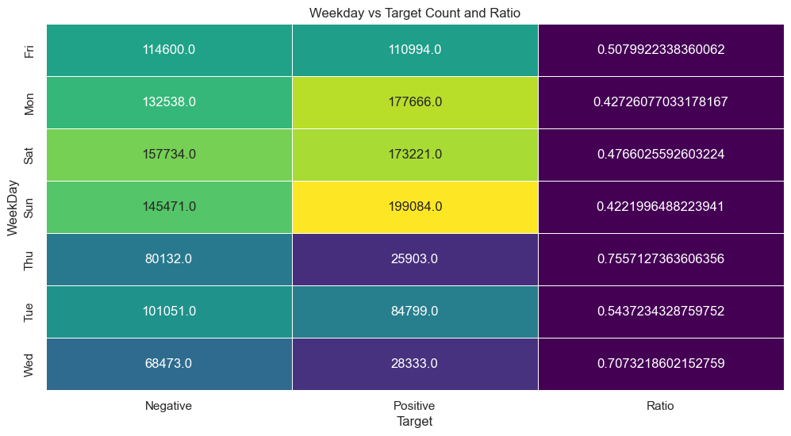

```python
pivot_table_weekday = df.groupby(['WeekDay', 'Target']).size().unstack(fill_value=0)

pivot_table_weekday['Ratio'] = pivot_table_weekday['Negative'] / (pivot_table_weekday['Negative'] +pivot_table_weekday['Positive'])

plt.figure(figsize=(12, 6))
sns.heatmap(pivot_table_weekday, annot=True, fmt='1',
            cmap='viridis', linewidths=.5, cbar_kws={'label': 'Count'}, cbar=False)
plt.title('Weekday vs Target Count and Ratio')
plt.show()
```

Analyzing the nature of human tweets based on the above chart involves making inferences about the sentiment and behavior of users on different days of the week. Here are some potential insights:

1. **Weekend Positivity:**
   - Weekends (Saturday and Sunday) generally exhibit a higher prevalence of positive tweets. Users may be more relaxed, enjoying leisure activities, or sharing positive experiences.
2. **Monday Optimism:**
   - Mondays show a notably higher prevalence of positive tweets compared to negative ones. This could be attributed to a more optimistic and positive outlook at the beginning of the workweek.
3. **Midweek Negativity:**
   - Wednesdays and Thursdays have a higher prevalence of negative tweets. This might be associated with midweek stress, work-related challenges, or a general dip in mood during these days.
4. **Friday Ambiguity:**
   - Fridays show a relatively balanced distribution between positive and negative tweets, with a slightly higher prevalence of negative tweets. This might indicate a mix of emotions as people approach the weekend.
5. **Tuesday Variability:**
   - Tuesdays show a relatively balanced distribution, with a slightly higher prevalence of negative tweets. This could suggest variability in users' sentiments on this day.